# Dimensionality Reduction

Kelvin Kilel

2/4/2022

# Specifying the Question

1. Dimensionality Reduction

This section of the project entails reducing the dataset to a low dimensional dataset using PCA. You will be required to perform your analysis and provide insights gained from your analysis.

2. Feature Selection

This section requires you to perform feature selection through the use of the unsupervised learning methods. You will be required to perform your analysis and provide insights on the features that contribute the most information to the dataset.

# Metrics od Success

1. Be able to provide insights gained from dimensionality reduction using PCA.
2. Be able to provide insights on the features that contribute most information to the dataset.

# Experimental Design

1. Problem Definition.
2. Reading the dataset.
3. Perform EDA.
4. Univariate Analysis.
5. Bivariate Analysis.
6. Dimensionality Reduction.
7. Feature Selection.

# Reading the Dataset

```r
library(data.table)
library(tidyverse)
link <- 'http://bit.ly/CarreFourDataset'
carrefour_df <- read_csv(link)
# Previewing the top records
head(carrefour_df)
```

```
## # A tibble: 6 × 16
##   `Invoice ID` Branch `Customer type` Gender `Product line`         `Unit price`
##   <chr>        <chr>  <chr>           <chr>  <chr>                         <dbl>
## 1 750-67-8428  A      Member          Female Health and beauty              74.7
## 2 226-31-3081  C      Normal          Female Electronic accessories         15.3
## 3 631-41-3108  A      Normal          Male   Home and lifestyle             46.3
## 4 123-19-1176  A      Member          Male   Health and beauty              58.2
## 5 373-73-7910  A      Normal          Male   Sports and travel              86.3
## 6 699-14-3026  C      Normal          Male   Electronic accessories         85.4
## # … with 10 more variables: Quantity <dbl>, Tax <dbl>, Date <chr>, Time <time>,
## #   Payment <chr>, cogs <dbl>, `gross margin percentage` <dbl>,
## #   `gross income` <dbl>, Rating <dbl>, Total <dbl>
```

```r
# Checking the dimension of the dataset
dim(carrefour_df)
```

```
## [1] 1000   16
```

```r
# Checking the data types
str(carrefour_df)
```

```
## spec_tbl_df [1,000 × 16] (S3: spec_tbl_df/tbl_df/tbl/data.frame)
##  $ Invoice ID             : chr [1:1000] "750-67-8428" "226-31-3081" "631-41-3108" "123-19-1176" ...
##  $ Branch                 : chr [1:1000] "A" "C" "A" "A" ...
##  $ Customer type          : chr [1:1000] "Member" "Normal" "Normal" "Member" ...
##  $ Gender                 : chr [1:1000] "Female" "Female" "Male" "Male" ...
##  $ Product line           : chr [1:1000] "Health and beauty" "Electronic accessories" "Home and lifestyle" "Health and beauty" ...
##  $ Unit price             : num [1:1000] 74.7 15.3 46.3 58.2 86.3 ...
##  $ Quantity               : num [1:1000] 7 5 7 8 7 7 6 10 2 3 ...
##  $ Tax                    : num [1:1000] 26.14 3.82 16.22 23.29 30.21 ...
##  $ Date                   : chr [1:1000] "1/5/2019" "3/8/2019" "3/3/2019" "1/27/2019" ...
##  $ Time                   : 'hms' num [1:1000] 13:08:00 10:29:00 13:23:00 20:33:00 ...
##   ..- attr(*, "units")= chr "secs"
##  $ Payment                : chr [1:1000] "Ewallet" "Cash" "Credit card" "Ewallet" ...
##  $ cogs                   : num [1:1000] 522.8 76.4 324.3 465.8 604.2 ...
##  $ gross margin percentage: num [1:1000] 4.76 4.76 4.76 4.76 4.76 ...
##  $ gross income           : num [1:1000] 26.14 3.82 16.22 23.29 30.21 ...
##  $ Rating                 : num [1:1000] 9.1 9.6 7.4 8.4 5.3 4.1 5.8 8 7.2 5.9 ...
##  $ Total                  : num [1:1000] 549 80.2 340.5 489 634.4 ...
##  - attr(*, "spec")=
##   .. cols(
##   ..   `Invoice ID` = col_character(),
##   ..   Branch = col_character(),
##   ..   `Customer type` = col_character(),
##   ..   Gender = col_character(),
##   ..   `Product line` = col_character(),
##   ..   `Unit price` = col_double(),
##   ..   Quantity = col_double(),
##   ..   Tax = col_double(),
##   ..   Date = col_character(),
##   ..   Time = col_time(format = ""),
##   ..   Payment = col_character(),
##   ..   cogs = col_double(),
##   ..   `gross margin percentage` = col_double(),
##   ..   `gross income` = col_double(),
##   ..   Rating = col_double(),
##   ..   Total = col_double()
##   .. )
##  - attr(*, "problems")=<externalptr>
```

```r
# Checking for summary
summary(carrefour_df)
```

```
##   Invoice ID           Branch          Customer type         Gender
##  Length:1000        Length:1000        Length:1000        Length:1000
##  Class :character   Class :character   Class :character   Class :character
##  Mode  :character   Mode  :character   Mode  :character   Mode  :character
##
##
##
##  Product line         Unit price       Quantity          Tax
##  Length:1000        Min.   :10.08   Min.   : 1.00   Min.   : 0.5085
##  Class :character   1st Qu.:32.88   1st Qu.: 3.00   1st Qu.: 5.9249
##  Mode  :character   Median :55.23   Median : 5.00   Median :12.0880
##                     Mean   :55.67   Mean   : 5.51   Mean   :15.3794
##                     3rd Qu.:77.94   3rd Qu.: 8.00   3rd Qu.:22.4453
##                     Max.   :99.96   Max.   :10.00   Max.   :49.6500
##      Date               Time            Payment               cogs
##  Length:1000        Length:1000       Length:1000        Min.   : 10.17
##  Class :character   Class1:hms        Class :character   1st Qu.:118.50
##  Mode  :character   Class2:difftime   Mode  :character   Median :241.76
##                     Mode  :numeric                       Mean   :307.59
##                                                          3rd Qu.:448.90
##                                                          Max.   :993.00
##  gross margin percentage  gross income         Rating           Total
##  Min.   :4.762           Min.   : 0.5085   Min.   : 4.000   Min.   :  10.68
##  1st Qu.:4.762           1st Qu.: 5.9249   1st Qu.: 5.500   1st Qu.: 124.42
##  Median :4.762           Median :12.0880   Median : 7.000   Median : 253.85
##  Mean   :4.762           Mean   :15.3794   Mean   : 6.973   Mean   : 322.97
##  3rd Qu.:4.762           3rd Qu.:22.4453   3rd Qu.: 8.500   3rd Qu.: 471.35
##  Max.   :4.762           Max.   :49.6500   Max.   :10.000   Max.   :1042.65
```

# Tidying the dataset

```r
colSums(is.na(carrefour_df))
```

```
##              Invoice ID                  Branch           Customer type
##                       0                       0                       0
##                  Gender            Product line              Unit price
##                       0                       0                       0
##                Quantity                     Tax                    Date
##                       0                       0                       0
##                    Time                 Payment                    cogs
##                       0                       0                       0
## gross margin percentage            gross income                  Rating
##                       0                       0                       0
##                   Total
##                       0
```

```r
# There are no missing values in the dataset.
```

```r
# Converting to a dataframe
new_df <- data.frame(carrefour_df)
```

```r
# creating uniformity in the column names

colnames(new_df) <- tolower(colnames(new_df))

# Previwing the top records to confirm changes

head(new_df)
```

```
##    invoice.id branch customer.type gender           product.line unit.price
## 1 750-67-8428      A        Member Female      Health and beauty      74.69
## 2 226-31-3081      C        Normal Female Electronic accessories      15.28
## 3 631-41-3108      A        Normal   Male     Home and lifestyle      46.33
## 4 123-19-1176      A        Member   Male      Health and beauty      58.22
## 5 373-73-7910      A        Normal   Male      Sports and travel      86.31
## 6 699-14-3026      C        Normal   Male Electronic accessories      85.39
##   quantity     tax      date     time     payment   cogs
## 1        7 26.1415  1/5/2019 13:08:00     Ewallet 522.83
## 2        5  3.8200  3/8/2019 10:29:00        Cash  76.40
## 3        7 16.2155  3/3/2019 13:23:00 Credit card 324.31
## 4        8 23.2880 1/27/2019 20:33:00     Ewallet 465.76
## 5        7 30.2085  2/8/2019 10:37:00     Ewallet 604.17
## 6        7 29.8865 3/25/2019 18:30:00     Ewallet 597.73
##   gross.margin.percentage gross.income rating    total
## 1                4.761905      26.1415    9.1 548.9715
## 2                4.761905       3.8200    9.6  80.2200
## 3                4.761905      16.2155    7.4 340.5255
## 4                4.761905      23.2880    8.4 489.0480
## 5                4.761905      30.2085    5.3 634.3785
## 6                4.761905      29.8865    4.1 627.6165
```

```r
# Checking for duplicates
duplicates <- new_df[duplicated(new_df),]

dim(duplicates)
```

```
## [1]  0 16
```

```r
# There are no duplicates.
```

```r
# Separating the numerical columns
num_cols <- subset(new_df, select = -c(
invoice.id,branch,customer.type,gender,product.line,date,time,payment, gross.margin.percentage))

head(num_cols)
```

```
##   unit.price quantity     tax   cogs gross.income rating    total
## 1      74.69        7 26.1415 522.83      26.1415    9.1 548.9715
## 2      15.28        5  3.8200  76.40       3.8200    9.6  80.2200
## 3      46.33        7 16.2155 324.31      16.2155    7.4 340.5255
## 4      58.22        8 23.2880 465.76      23.2880    8.4 489.0480
## 5      86.31        7 30.2085 604.17      30.2085    5.3 634.3785
## 6      85.39        7 29.8865 597.73      29.8865    4.1 627.6165
```

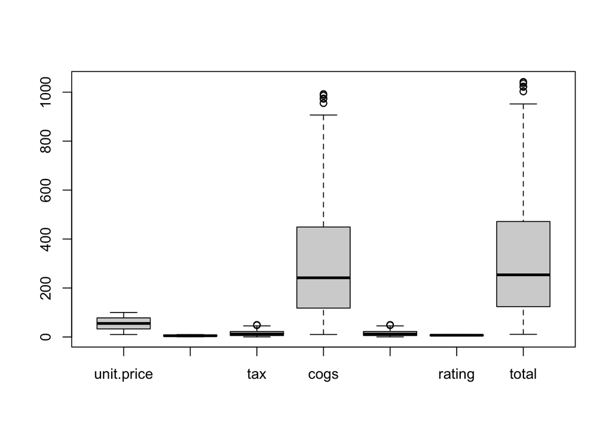

```r
# Checking for outliers

boxplot(num_cols)
```

# Univariate Analysis

```r
library(psych)
describe(num_cols)
```

```
##              vars    n   mean     sd median trimmed    mad   min     max
## unit.price      1 1000  55.67  26.49  55.23   55.62  33.37 10.08   99.96
## quantity        2 1000   5.51   2.92   5.00    5.51   2.97  1.00   10.00
## tax             3 1000  15.38  11.71  12.09   14.00  11.13  0.51   49.65
## cogs            4 1000 307.59 234.18 241.76  279.91 222.65 10.17  993.00
## gross.income    5 1000  15.38  11.71  12.09   14.00  11.13  0.51   49.65
## rating          6 1000   6.97   1.72   7.00    6.97   2.22  4.00   10.00
## total           7 1000 322.97 245.89 253.85  293.91 233.78 10.68 1042.65
##                range skew kurtosis   se
## unit.price     89.88 0.01    -1.22 0.84
## quantity        9.00 0.01    -1.22 0.09
## tax            49.14 0.89    -0.09 0.37
## cogs          982.83 0.89    -0.09 7.41
## gross.income   49.14 0.89    -0.09 0.37
## rating          6.00 0.01    -1.16 0.05
## total        1031.97 0.89    -0.09 7.78
```

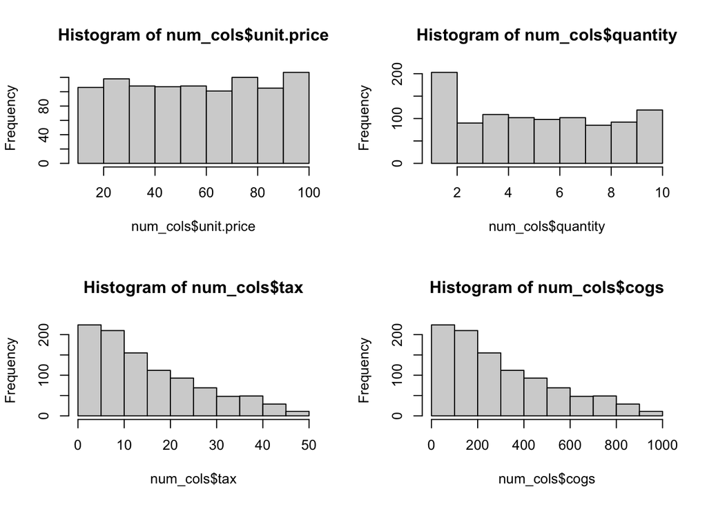

```r
par(mfrow = c(2, 2))
hist(num_cols$unit.price)
hist(num_cols$quantity)
hist(num_cols$tax)
hist(num_cols$cogs)
```

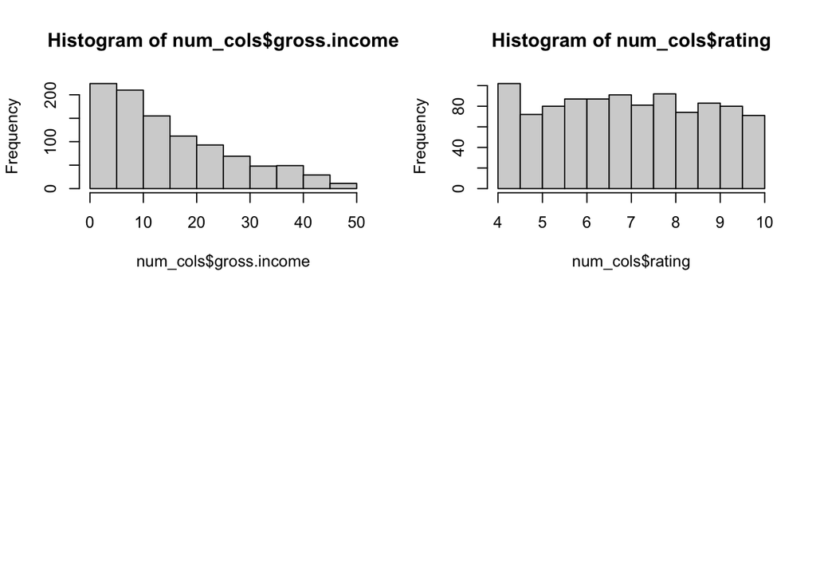

```r
hist(num_cols$gross.income)
hist(num_cols$rating)
```

The graphs above show that the attributes in our dataset do not have a normal distribution.

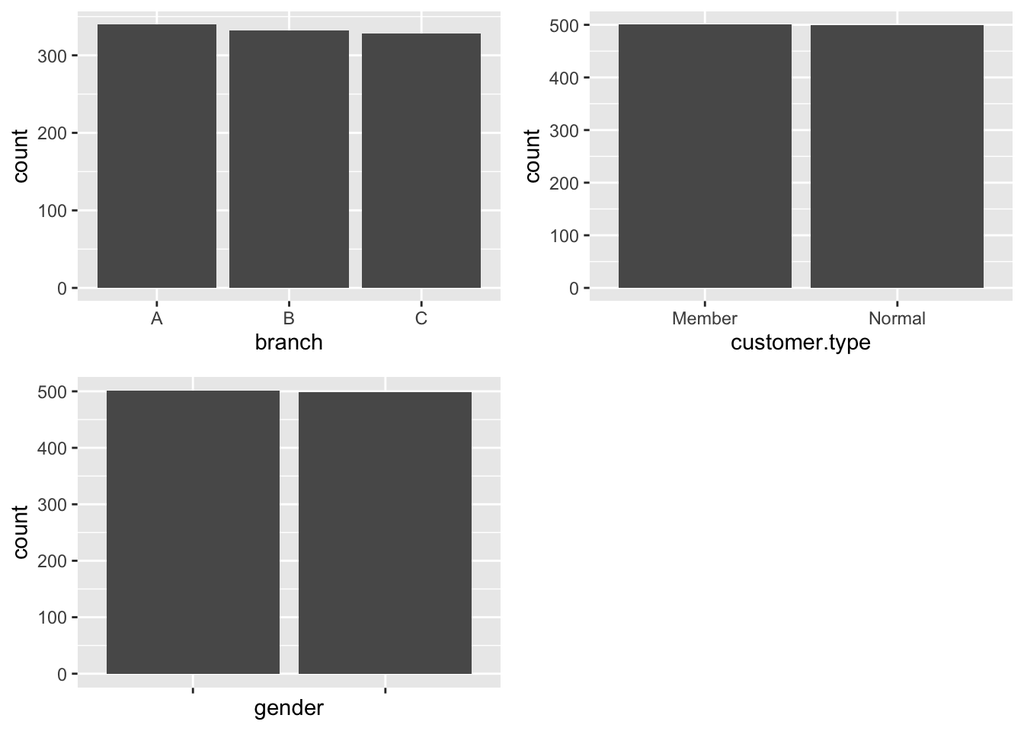

```r
library(ggpubr)

b <- ggplot(data = new_df) +
  geom_bar(mapping = aes(x = branch))

c <- ggplot(data = new_df) +
  geom_bar(mapping = aes(x = customer.type))

g <- ggplot(data = new_df) +
  geom_bar(mapping = aes(x = gender))
ggarrange(b, c, g + rremove("x.text"),
          ncol = 2, nrow = 2)
```

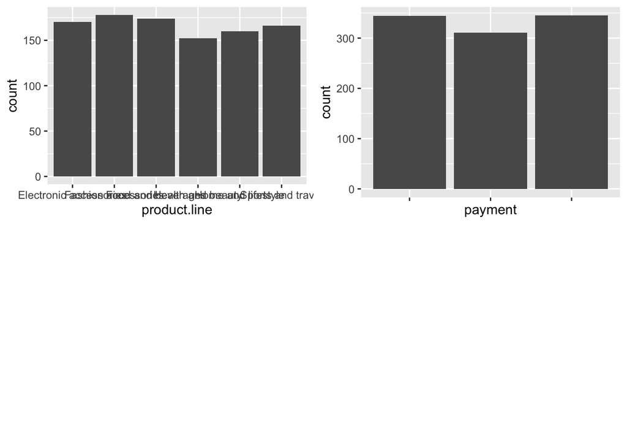

```r
pr <- ggplot(data = new_df) +
  geom_bar(mapping = aes(x = product.line))

pa <- ggplot(data = new_df) +
  geom_bar(mapping = aes(x = payment))
ggarrange( pr, pa + rremove("x.text"),
          ncol = 2, nrow = 2)
```

All branches had almost equal sales.

Both members and normal customer types had equal contribution to the total sales.

Both male and female had almost equal contribution to the total sales.

Electronic accessories, Fashion accessories and food and beverages had high sales.

# Bivariate Analysis

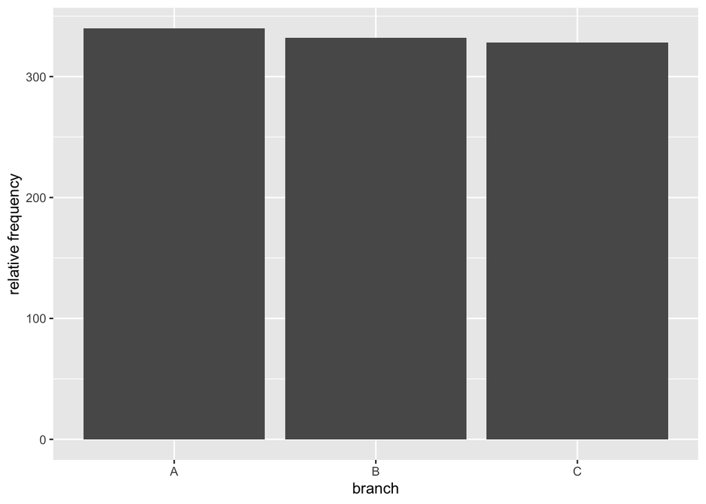

```r
new_df %>%
  ggplot() +
  aes(x = branch, total = ..count../nrow(new_df), fill = total) +
  geom_bar() +
  ylab("relative frequency")
```

Branch A has slightly higher total sales.

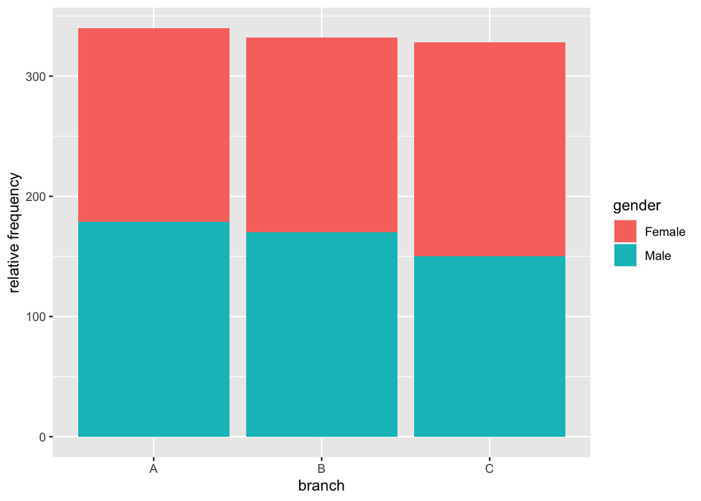

```r
new_df %>%
  ggplot() +
  aes(x = branch, total = ..count../nrow(new_df), fill = gender) +
  geom_bar() +
  ylab("relative frequency")
```

There were approximately equal number of male customers to female customers in each branch.

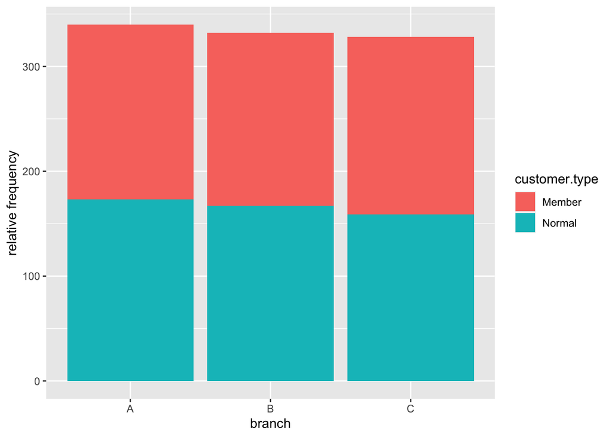

```r
new_df %>%
  ggplot() +
  aes(x = branch, total = ..count../nrow(new_df), fill = customer.type) +
  geom_bar() +
  ylab("relative frequency")
```

Members and normal customer types had equal sales in each branch.

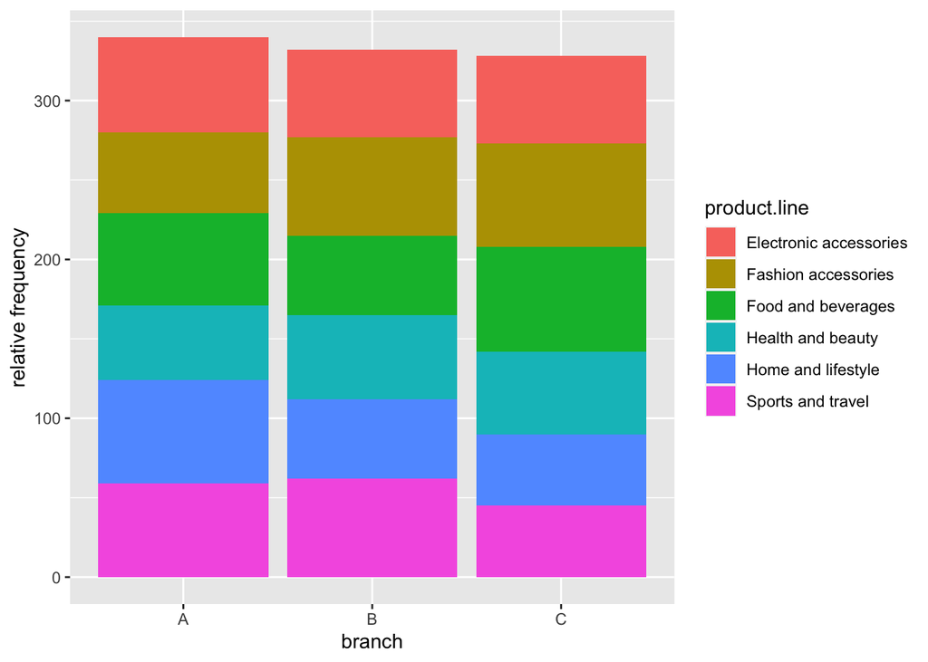

```r
new_df %>%
  ggplot() +
  aes(x = branch, total = ..count../nrow(new_df), fill = product.line) +
  geom_bar() +
  ylab("relative frequency")
```

Branch C had less sale of sports and travel items compared to the other branches. Branch A had more sales on home and lifestyle items compared to the other branches.

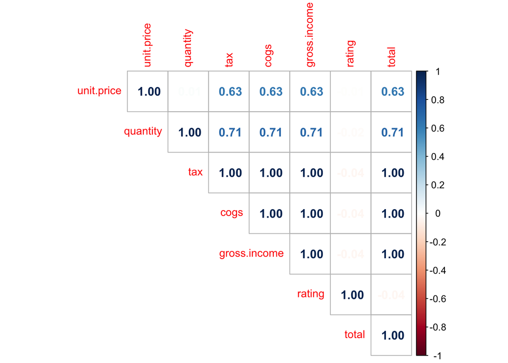

```r
library(corrplot)
corrplot(cor(num_cols), type= 'upper', method = 'number', tl.cex = 0.9)
```

Tax and quantity are highly correlated positively.

Gross income and tax, COGS and Tax, and COGS and Gross Income are perfectly correlated.

# Dimensionality Reduction using PCA

#### Feature Engineering

```r
# Dropping the columns that we will not require i.e date, time
pca_df <- subset(new_df, select = -c(invoice.id, date, time, gross.margin.percentage))
head(pca_df)
```

```
##   branch customer.type gender           product.line unit.price quantity
## 1      A        Member Female      Health and beauty      74.69        7
## 2      C        Normal Female Electronic accessories      15.28        5
## 3      A        Normal   Male     Home and lifestyle      46.33        7
## 4      A        Member   Male      Health and beauty      58.22        8
## 5      A        Normal   Male      Sports and travel      86.31        7
## 6      C        Normal   Male Electronic accessories      85.39        7
##       tax     payment   cogs gross.income rating    total
## 1 26.1415     Ewallet 522.83      26.1415    9.1 548.9715
## 2  3.8200        Cash  76.40       3.8200    9.6  80.2200
## 3 16.2155 Credit card 324.31      16.2155    7.4 340.5255
## 4 23.2880     Ewallet 465.76      23.2880    8.4 489.0480
## 5 30.2085     Ewallet 604.17      30.2085    5.3 634.3785
## 6 29.8865     Ewallet 597.73      29.8865    4.1 627.6165
```

```r
# Converting the categorical character columns to numericals
## Converting to factors first
pca_df$branch <- as.factor(pca_df$branch)
pca_df$customer.type <- as.factor(pca_df$customer.type)
pca_df$gender <- as.factor(pca_df$gender)
pca_df$product.line <- as.factor(pca_df$product.line)
pca_df$payment <- as.factor(pca_df$payment)

## Converting to numerics
pca_df$branch <- as.numeric(pca_df$branch)
pca_df$customer.type <- as.numeric(pca_df$customer.type)
pca_df$gender <- as.numeric(pca_df$gender)
pca_df$product.line <- as.numeric(pca_df$product.line)
pca_df$payment <- as.numeric(pca_df$payment)

head(pca_df)
```

```
##   branch customer.type gender product.line unit.price quantity     tax payment
## 1      1             1      1            4      74.69        7 26.1415       3
## 2      3             2      1            1      15.28        5  3.8200       1
## 3      1             2      2            5      46.33        7 16.2155       2
## 4      1             1      2            4      58.22        8 23.2880       3
## 5      1             2      2            6      86.31        7 30.2085       3
## 6      3             2      2            1      85.39        7 29.8865       3
##     cogs gross.income rating    total
## 1 522.83      26.1415    9.1 548.9715
## 2  76.40       3.8200    9.6  80.2200
## 3 324.31      16.2155    7.4 340.5255
## 4 465.76      23.2880    8.4 489.0480
## 5 604.17      30.2085    5.3 634.3785
## 6 597.73      29.8865    4.1 627.6165
```

```r
pca_df.pca <- prcomp(pca_df[, c(1:11)], centre = TRUE, scale. = TRUE)
summary(pca_df.pca)
```

```
## Importance of components:
##                           PC1    PC2     PC3     PC4     PC5    PC6     PC7
## Standard deviation     1.9836 1.0631 1.03159 1.00991 0.99289 0.9771 0.96270
## Proportion of Variance 0.3577 0.1027 0.09674 0.09272 0.08962 0.0868 0.08425
## Cumulative Proportion  0.3577 0.4604 0.55719 0.64991 0.73953 0.8263 0.91058
##                            PC8     PC9      PC10      PC11
## Standard deviation     0.94823 0.29062 2.736e-16 1.109e-16
## Proportion of Variance 0.08174 0.00768 0.000e+00 0.000e+00
## Cumulative Proportion  0.99232 1.00000 1.000e+00 1.000e+00
```

We have obtained 11 principal components, where each explains a percentate of the total variation of the dataset PC1 explains 35.7% of the total variance, PC2 explains 10.27% of the variance etc.

```r
# Calling str() to have a look at your PCA object
str(pca_df.pca)
```

```
## List of 5
##  $ sdev    : num [1:11] 1.984 1.063 1.032 1.01 0.993 ...
##  $ rotation: num [1:11, 1:11] 0.0267 -0.0155 -0.0338 0.0206 0.3273 ...
##   ..- attr(*, "dimnames")=List of 2
##   .. ..$ : chr [1:11] "branch" "customer.type" "gender" "product.line" ...
##   .. ..$ : chr [1:11] "PC1" "PC2" "PC3" "PC4" ...
##  $ center  : Named num [1:11] 1.99 1.5 1.5 3.45 55.67 ...
##   ..- attr(*, "names")= chr [1:11] "branch" "customer.type" "gender" "product.line" ...
##  $ scale   : Named num [1:11] 0.818 0.5 0.5 1.715 26.495 ...
##   ..- attr(*, "names")= chr [1:11] "branch" "customer.type" "gender" "product.line" ...
##  $ x       : num [1:1000, 1:11] 1.79 -2.05 0.11 1.29 2.43 ...
##   ..- attr(*, "dimnames")=List of 2
##   .. ..$ : chr [1:1000] "1" "2" "3" "4" ...
##   .. ..$ : chr [1:11] "PC1" "PC2" "PC3" "PC4" ...
##  - attr(*, "class")= chr "prcomp"
```

Here we have a look at the pca object: 1. The center point ($center), scaling ($scale), standard deviation(sdev) of each principal component. 2. The relationship (correlation or anticorrelation, etc) between the initial variables and the principal components ($rotation). 3. The values of each sample in terms of the principal components.

```r
# Plotting pca to get insights

#install.packages("devtools")
library(devtools)
install_github("vqv/ggbiplot")
```

```
## Skipping install of 'ggbiplot' from a github remote, the SHA1 (7325e880) has not changed since last install.
##   Use `force = TRUE` to force installation
```

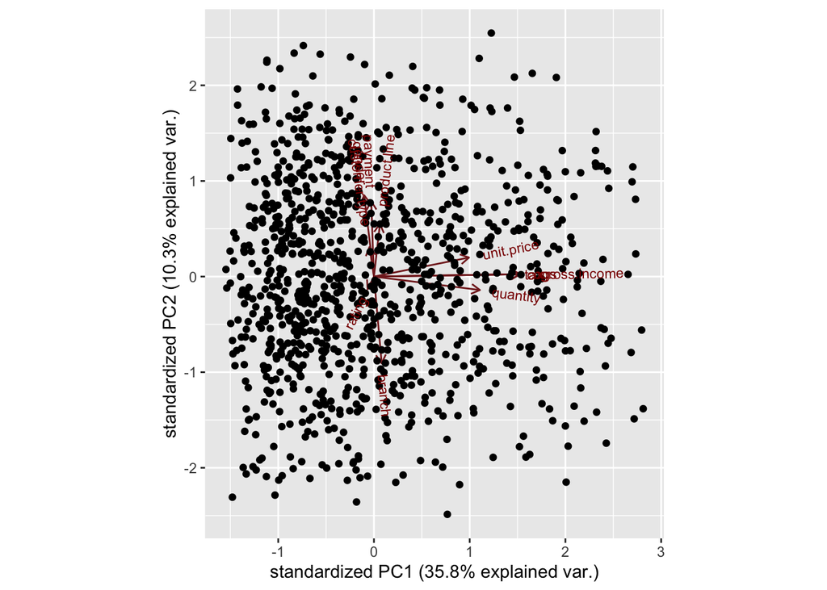

```r
# Then Loading ggbiplot library
library(ggbiplot)
ggbiplot(pca_df.pca)
```

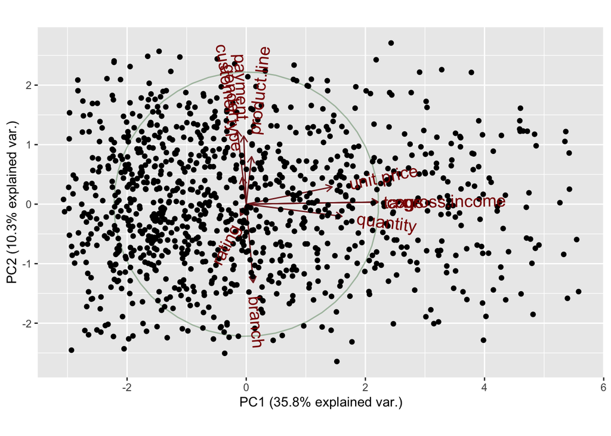

```r
bplot = ggbiplot(pcobj = pca_df.pca,
         choices = c(1,2),
         obs.scale = 1, var.scale = 1,
         varname.size = 5,
         varname.abbrev = FALSE,
         var.axes = TRUE,
         circle = TRUE)
print(bplot)
```

```r
#install.packages("factoextra")
library(factoextra)
```

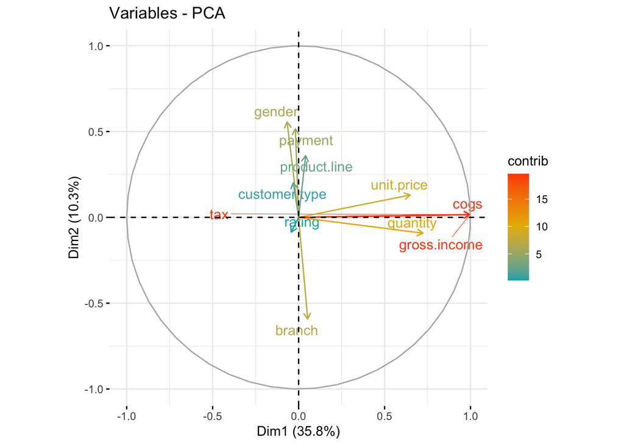

```r
fviz_pca_var(pca_df.pca,
             col.var = "contrib", # Color contribution to PC
             gradient.cols = c("#00AFBB", "#E7B800", "#FC4E07"),
             repel = TRUE # Avoid text overlapping
            )
```

Our graphs show that PC1 contributes 35.8%. Unit price, cogs, tax, gross income and quantity contribute to PC1.

# Feature Selection using Filter Method

```r
library(caret)
# preapring our data
feat_df <- pca_df[-12]
```

```r
# Calculating the correlation matrix
CorrelationMatrix <- cor(feat_df)
```

```r
# Find the attributes that are highly correlated
highlycorrelated <- findCorrelation(CorrelationMatrix, cutoff=0.75)
```

```r
# Highly Correlated Attributes

names(feat_df[,highlycorrelated])
```

```
## [1] "tax"  "cogs"
```

```r
# Dropping the highly correlated attributes
feat_df2 <- feat_df[-highlycorrelated]
```

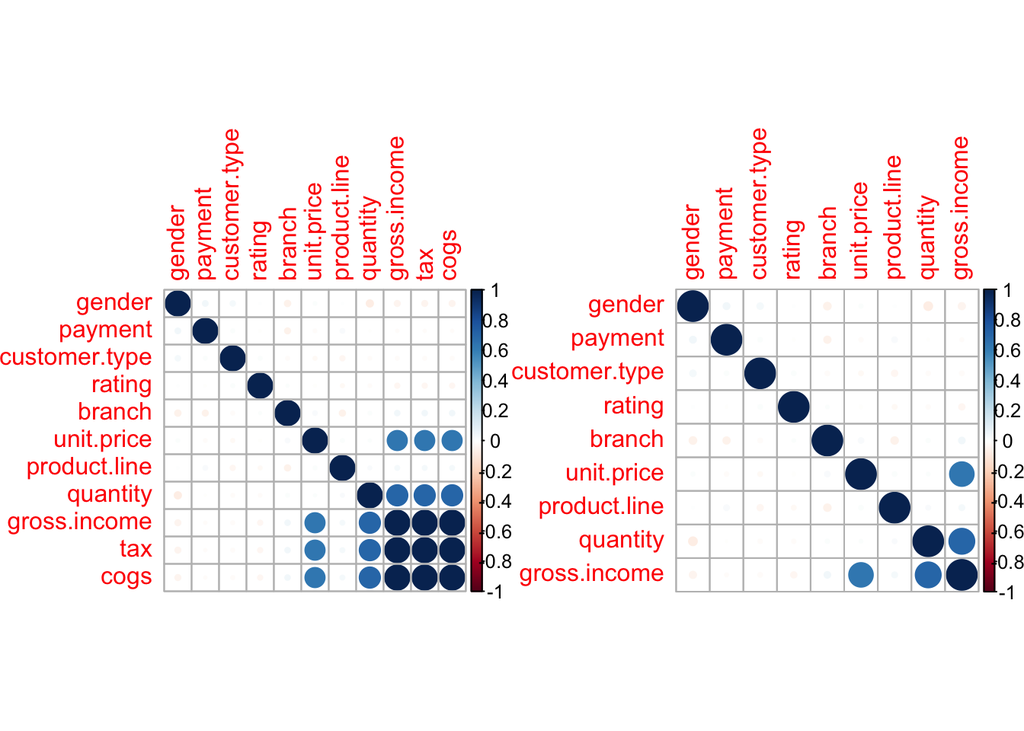

```r
# Performing Graphical Comparison
par(mfrow = c(1, 2))
corrplot(CorrelationMatrix, order = "hclust")
corrplot(cor(feat_df2), order = "hclust")
```

```r
# The important features for analysis are:
names(feat_df2)
```

```
## [1] "branch"        "customer.type" "gender"        "product.line"
## [5] "unit.price"    "quantity"      "payment"       "gross.income"
## [9] "rating"
```